# MABAn Consulting Case

Manuela Giansante, Emily Schmidt, Francisco Arrieta, Lucia Camenisch, Camille Valera, Oumaima Al Qoh

2023-05-05

```r
#necessary packages
library(data.table)
library(ggplot2)
library(e1071)
library(missForest)
library(caret)
library(MASS)
library(gridExtra)
library(fabletools)
library(forecast)
library(feasts)
library(forcats)
```

## Purpose of the case-study:

The purpose of this case study is to see if these three measures (i.e. CD4, CD8 and RNA counts) provide ‘discrimination’ between two groups of couples classified as ‘Discordinant’ (DP: only one partner HIV-positive) and ‘Concordinant’ (CP: both HIV-positive). Only one partner from each couple was included in the study, with the infected partner being measured in the DP group. This provided a more homogeneous cohort, and to eliminate confounding effects, drug users and nonmonogamous couples were excluded.

So the purpose of our case study is to predict whether the couple is concordinant or discordinant. The performance of this classification job is outside of the scope of what we want to ask you. But we thought to include it for clarity. The main job is to understand what of the 3 variables (cd4, cd8, rna) is most important in the prediction. Now this is something that must be done with machine learning methods. What we want to interrogate you on is if the behaviour of the data we are provided with seems realistic enough or if we should expect something else.

We will try to go throught eveyrthing in the most efficient way so to not take up much of your time. Thank you, for you attention!

## Importing the data and first exploration

We import the data set, we will describe it briefly the best we can, to also indicate what we know.

– sex: gender of patient (f = ‘female’, m = ‘male’); – type: ‘CP’ if both patient and their partner are infected, ‘DP’ if patient’s partner is not infected; – cd4, cd8, rna: cell counts of patient

```r
# Import the data
aids <- fread("Caids.csv")
aids
```

```
##      sex type  cd4  cd8 rna
##   1:   m   DP   50 1569 500
##   2:   m   DP   99 1174 500
##   3:   m   DP  178 1169 500
##   4:   m   DP  217  326 500
##   5:   f   CP  232  718 500
##  ---
## 274:   f   DP  886 1716  NA
## 275:   m   DP  911 1551  NA
## 276:   m   DP  990 1097  NA
## 277:   m   DP 1104 1325  NA
## 278:   m   DP 1128  668  NA
```

```r
# format transformations to use plotting functions
aids[, sex := as.factor(sex)]
aids[, type := as.factor(type)]

# here we are selectign all the rows in the aids data set which has missing values
new_DF <- aids[rowSums(is.na(aids)) > 0,]
```

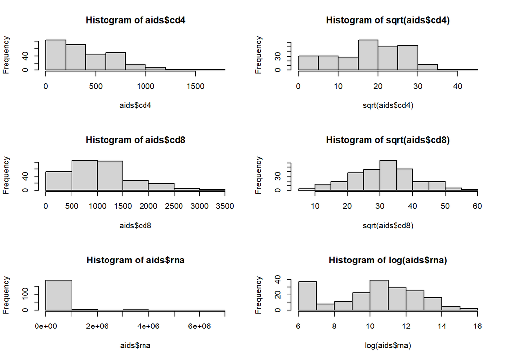

```r
# Plot the data
par(mfrow = c(3,2))

hist(aids$cd4)
hist(sqrt(aids$cd4))# square root
hist(aids$cd8)
hist(sqrt(aids$cd8)) # square root
hist(aids$rna)
hist(log(aids$rna))# natural log of the rna data
```

### Histograms of cd4,cd8, rna by type (DP, CP)

Here, what we want to observe how the cd4, cd8 and rna distributes depending on whether the couple is ‘Discordinant’ (DP) or ‘Concordinant’ (CP):

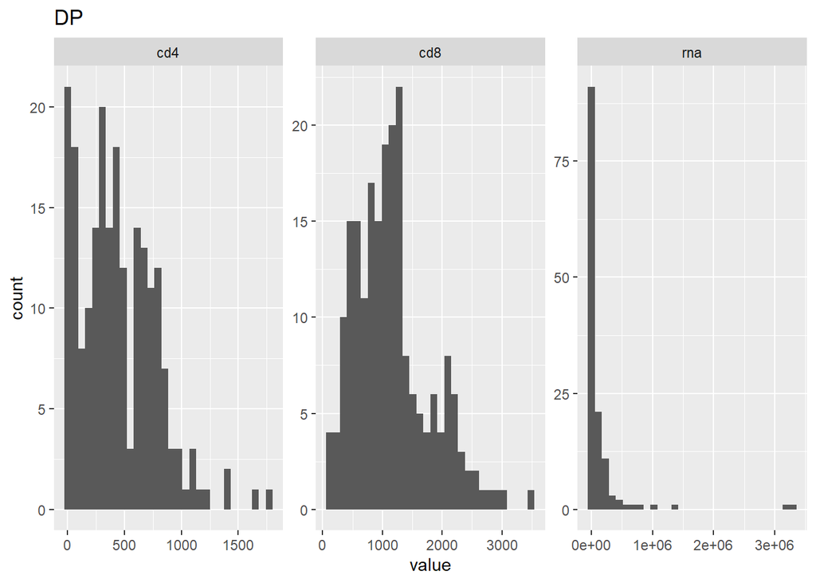

```r
# the melt function is only a re-organizaiton of the data table we need to perform
# to be able to plot these data divided by DP and CP
aids_melt <- melt(aids[, -1], id.vars = "type")

# bar plots
ggplot(data = aids_melt[type %in% "DP",], aes(value)) + geom_histogram() +
  facet_wrap(~ variable, scales = "free") +
  labs(title = "DP")
```

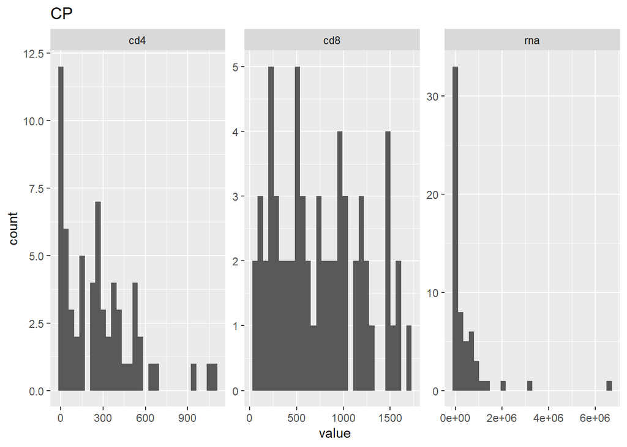

```r
ggplot(data = aids_melt[type %in% "CP",], aes(value)) + geom_histogram() +
  facet_wrap(~ variable, scales = "free") +
  labs(title = "CP")
```

## Correlation matrix of cd4, cd8, rna

We reporta very simple correlation matrix of these 3 measures:

```r
cor(aids[, 3:5], use = "complete.obs")
```

```
##            cd4        cd8        rna
## cd4  1.0000000  0.4677712 -0.2148074
## cd8  0.4677712  1.0000000 -0.1109255
## rna -0.2148074 -0.1109255  1.0000000
```

- cd8 and rna are not highly correlated;
- neither are cd4 and rna;
- cd4 and cd8 are the most correlated pair

# Skewdness of the transformed data

```r
skewness(sqrt(aids$cd4), na.rm = TRUE)
```

```
## [1] -0.07158787
```

```r
skewness(sqrt(aids$cd8), na.rm = TRUE)
```

```
## [1] 0.02813358
```

```r
skewness(log(aids$rna), na.rm = TRUE)
```

```
## [1] -0.2373007
```

This is performed to just gather how not normally distributed these measures are. (normally distributed -> bell shaped distribution plot)

## Scatter plot of untrasformed data (not normally distributed)

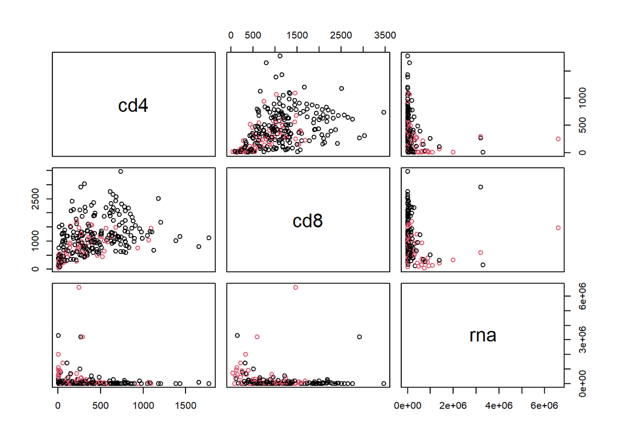

```r
# here we simply code the categorical values to be dummies
aids[, sex := ifelse(sex == "m", 0, 1)] # 0 for male, 1 for female
aids[, type := ifelse(type == "DP", 0, 1)] # 0 for discordinant, 1 for concordinant couple

# scatter plot of cd4, cd8, rna based on type
plot(aids[, 3:5], col = as_factor(aids$type))
```

```r
# summary of the data:
# main statistics and how many missing values (NAs) are for each columns
summary(aids)
```

```
##       sex             type            cd4              cd8
##  Min.   :0.000   Min.   :0.000   Min.   :   3.0   Min.   :  46.0
##  1st Qu.:0.000   1st Qu.:0.000   1st Qu.: 140.0   1st Qu.: 597.5
##  Median :0.000   Median :0.000   Median : 347.0   Median :1000.0
##  Mean   :0.223   Mean   :0.241   Mean   : 402.1   Mean   :1061.4
##  3rd Qu.:0.000   3rd Qu.:0.000   3rd Qu.: 627.5   3rd Qu.:1328.5
##  Max.   :1.000   Max.   :1.000   Max.   :1776.0   Max.   :3466.0
##                                  NA's   :3        NA's   :3
##       rna
##  Min.   :    500
##  1st Qu.:   4600
##  Median :  35000
##  Mean   : 229027
##  3rd Qu.: 155000
##  Max.   :6600000
##  NA's   :83
```

We coloured the points based on whether the couple is DP or CP. The proposed scatterplot plots how the 3 measures we are interested in behave against one another

**Is their behaviour particularly uncommon, what one should expect in a real life case?**

- cd8 vs rna (row 2, column 3 & row 3, column 2): as rna grows, cd8 does not. They had a small correlation, do they usually move together? or do they not? this non-correlated behaviour is it something that we should expect?
- cd8 vs cd4 (row 1, column 2 & row 2, column 1) : we saw that they had an almost 0.5 correlation in fact we see that they are directly proportional to one another.
- cd4 vs rna (row 3, column 1 & row 1, column 3): as cd4 grows, rna does not it seems to remain in low levels

*to be reminded that her we are still dealing with a data set that has a lot of missing values*

## Populating the data

So when we imported the data, we saw that there were lot of missing values especially in the rna measure. What we decided to do is to “populated”/ randomly re-sample those missing values. We do so because otherwise the already small data-set would be reduced to a too small data-set, which for statistical reasons is not good. We would not be able to gather significant informations and conclusions from such a small data set.

`missForest()` is a function from the missForest package in R that imputes missing values in a dataset using a random forest algorithm. `variablewise = TRUE` specifies that the imputation should be done separately for each variable in the dataset.

**From documentation of the function:** ‘missForest’ is used to impute missing values particularly in the case of mixed-type data. It can be used to impute continuous and/or categorical data including complex interactions and non-linear relations. It yields an out-of-bag (OOB) imputation error estimate. Moreover, it can be run parallel to save computation time.

```r
# repopulation of the dtaa
aids_completed <- missForest(aids, variablewise = TRUE)

summary(aids)
```

```
##       sex             type            cd4              cd8
##  Min.   :0.000   Min.   :0.000   Min.   :   3.0   Min.   :  46.0
##  1st Qu.:0.000   1st Qu.:0.000   1st Qu.: 140.0   1st Qu.: 597.5
##  Median :0.000   Median :0.000   Median : 347.0   Median :1000.0
##  Mean   :0.223   Mean   :0.241   Mean   : 402.1   Mean   :1061.4
##  3rd Qu.:0.000   3rd Qu.:0.000   3rd Qu.: 627.5   3rd Qu.:1328.5
##  Max.   :1.000   Max.   :1.000   Max.   :1776.0   Max.   :3466.0
##                                  NA's   :3        NA's   :3
##       rna
##  Min.   :    500
##  1st Qu.:   4600
##  Median :  35000
##  Mean   : 229027
##  3rd Qu.: 155000
##  Max.   :6600000
##  NA's   :83
```

```r
#   imputed data matrix of same type as 'xmis'.
summary(aids_completed$ximp)
```

```
##       sex             type            cd4              cd8
##  Min.   :0.000   Min.   :0.000   Min.   :   3.0   Min.   :  46.0
##  1st Qu.:0.000   1st Qu.:0.000   1st Qu.: 141.0   1st Qu.: 596.2
##  Median :0.000   Median :0.000   Median : 346.5   Median : 996.0
##  Mean   :0.223   Mean   :0.241   Mean   : 401.0   Mean   :1059.0
##  3rd Qu.:0.000   3rd Qu.:0.000   3rd Qu.: 626.5   3rd Qu.:1325.8
##  Max.   :1.000   Max.   :1.000   Max.   :1776.0   Max.   :3466.0
##       rna
##  Min.   :    500
##  1st Qu.:  14250
##  Median :  48526
##  Mean   : 203796
##  3rd Qu.: 148237
##  Max.   :6600000
```

We now rename our data set to be the completed data set

```r
aids <- aids_completed$ximp
aids
```

```
##      sex type  cd4  cd8      rna
##   1:   0    0   50 1569   500.00
##   2:   0    0   99 1174   500.00
##   3:   0    0  178 1169   500.00
##   4:   0    0  217  326   500.00
##   5:   1    1  232  718   500.00
##  ---
## 274:   1    0  886 1716 19176.87
## 275:   0    0  911 1551 42110.34
## 276:   0    0  990 1097 44450.18
## 277:   0    0 1104 1325 37924.88
## 278:   0    0 1128  668 60798.21
```

#### Histograms of populated cd4, cd8 and rna

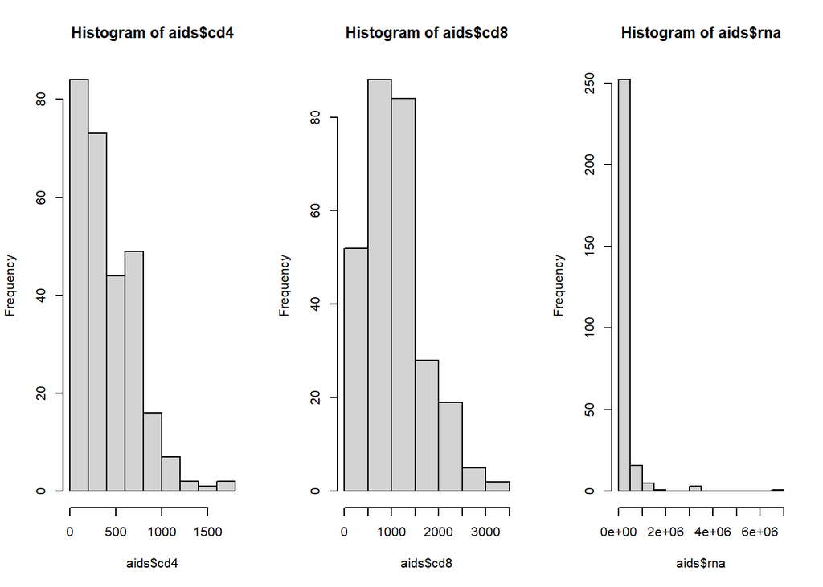

```r
par(mfrow = c(1,3))
hist(aids$cd4)
hist(aids$cd8)
hist(aids$rna)
```

```r
# correlation and scatterplot
cor(aids[, c(3,4,5)])
```

```
##            cd4        cd8        rna
## cd4  1.0000000  0.4329881 -0.2273022
## cd8  0.4329881  1.0000000 -0.1036955
## rna -0.2273022 -0.1036955  1.0000000
```

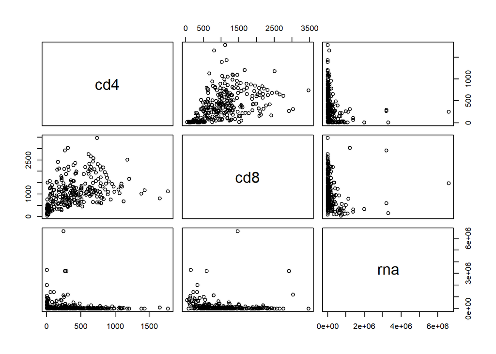

```r
plot(aids[, c(3,4,5)])
```

Plotting the densities/distributions of the completed data set variables. They still do not appear to be normally distributed. The scatter plot are of the not normalized but re-populated data.

## BoxCox transformation

Here we transform our continuous variables to be normally distributed. We also report this section, because we thought it would be important for the sake of completion and clarity. We do not know if this transformation is considered appropriate in the filed. But to use machine learning methods, we must fulfil some assumptions the statistical models make. We do not report the prediction models performed because it is outside of the scope of our question.

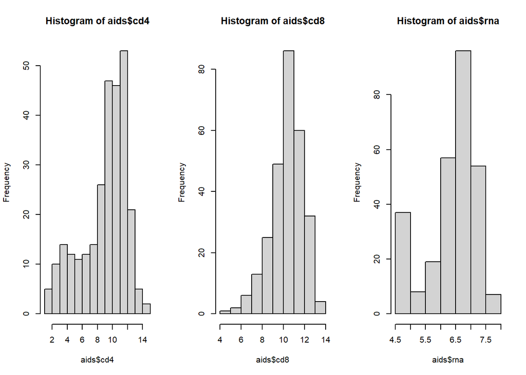

```r
# selection of optimal boxcox parameter for the tranformation
# the optimal lamda will allows us to have normally distrbuted variables
lambda1<-BoxCox.lambda(aids$cd4)
lambda2<-BoxCox.lambda(aids$cd8)
lambda3<-BoxCox.lambda(aids$rna)

# transformation
aids$cd4 <-  BoxCox(aids$cd4, lambda1)
aids$cd8 <-  BoxCox(aids$cd8, lambda2)
aids$rna <-  BoxCox(aids$rna, lambda3)

# Transformed data scatter plots
par(mfrow = c(1,3))
hist(aids$cd4)
hist(aids$cd8)
hist(aids$rna)
```

```r
#correlation and scatter plot
cor(aids[, c(3,4,5)])
```

```
##            cd4        cd8        rna
## cd4  1.0000000  0.6716456 -0.4434460
## cd8  0.6716456  1.0000000 -0.3279684
## rna -0.4434460 -0.3279684  1.0000000
```

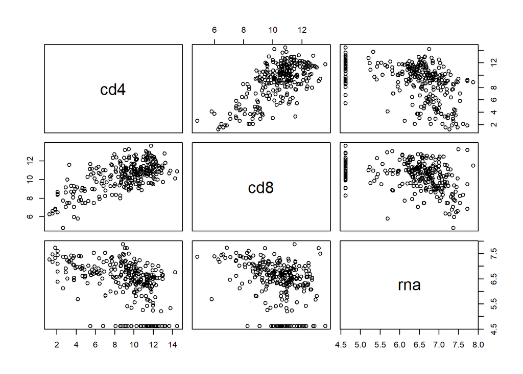

```r
plot(aids[, c(3,4,5)])
```

We conclude here, thank you for your attention!